# wk9_distributions

**The Graduate Record Exam (GRE) has a combined verbal and quantitative mean of 1000 and a standard deviation of 200. Scores range from 200 to 1600 and are approximately normally distributed. For each of the following problems draw a Rough Sketch, darkening in the portion of the curve that relates to the answer.**

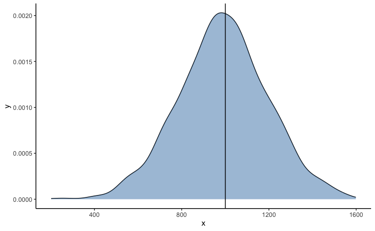

**1. What percentage of persons who take the exam score above 1300?**

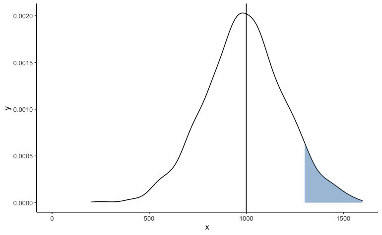

**2. What percentage score above 800?**

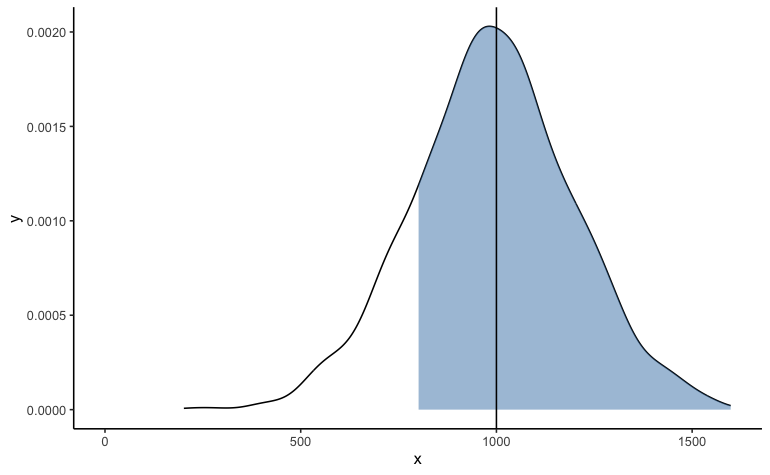

**3. What percentage score below 1200?**

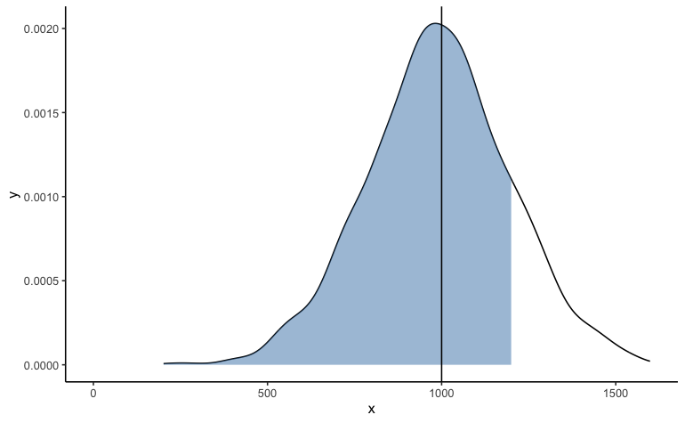

**SAT data are a symmetrical distribution. The scores range from 200-2400. The Mean score is 1300 with a standard deviation of 300.**

**1) Draw this distribution, making sure to label the standard deviations on your graph.**

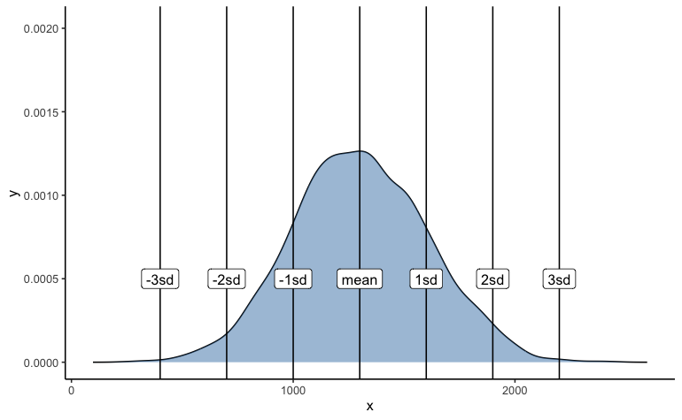

**2) What does the Standard Deviation mean?** The standard deviation is the amount the group varies from the mean. I like to think of it as the mean deviation of the mean, because you’re doing something similar to a mean calculation by making even cuts of the distribution.

**3) If a student scores 2 standard deviations below the mean, what score did they receive? What does this score mean?**

Two standard deviations ($\sigma = 300$) below a mean of $\bar X = 1300$ would be 700.

**4) If a student scores a 1700, what percentile did the student score in? What does this mean?**

```r
pnorm(1700,mean = 1300, sd = 300)
```

```
[1] 0.9087888
```

This would put a student scoring 1700 at just above the 90th percentile (~91st). That means that this student scored better than 91% of the sampled group. Alternatively, only 9% of students scored better than 1700.

**5) What percentile would a student who scores a 1000 be in?**

```r
pnorm(1000,mean = 1300, sd = 300)
```

```
[1] 0.1586553
```

Around the 16th percentile.

**6) What percentage of students score above 1900?**

```r
1-pnorm(1900,mean = 1300, sd = 300)
```

```
[1] 0.02275013
```

Just 2% of students scored over 1900.